# Lab Seven: RNNs

# Data overview

This data set is the review given by customer to the hotel. And also have variable ls_response which show whether customer is happy with the hotel services or not. 0 is unhappy and 1 is happy. There are 38932 records and no na value.

```python
#https://www.kaggle.com/anu0012/hotel-review
#0 unhappy
#1 happy
```

```python
import pandas as pd
import numpy as np
dfraw = pd.read_csv('hotel.csv')
print(dfraw.info())
```

```
<class 'pandas.core.frame.DataFrame'>
RangeIndex: 38932 entries, 0 to 38931
Data columns (total 5 columns):
User_ID         38932 non-null object
Description     38932 non-null object
Browser_Used    38932 non-null object
Device_Used     38932 non-null object
Is_Response     38932 non-null int64
dtypes: int64(1), object(4)
memory usage: 1.5+ MB
None
```

Id, browser_used, Device_used are not useful, I only want to analysis the text variable and the reponse.

```python
df = dfraw[['Description','Is_Response']]
df.dropna(inplace=True)
print(df.info())
```

```
<class 'pandas.core.frame.DataFrame'>
Int64Index: 38932 entries, 0 to 38931
Data columns (total 2 columns):
Description    38932 non-null object
Is_Response    38932 non-null int64
dtypes: int64(1), object(1)
memory usage: 912.5+ KB
None
```

```python
X = df['Description']
y = df['Is_Response']
df.head()
```

|  | Description | Is_Response |
| --- | --- | --- |
| 0 | The room was kind of clean but had a VERY stro... | 0 |
| 1 | I stayed at the Crown Plaza April -- - April -... | 0 |
| 2 | I booked this hotel through Hotwire at the low... | 0 |
| 3 | Stayed here with husband and sons on the way t... | 1 |
| 4 | My girlfriends and I stayed here to celebrate ... | 0 |

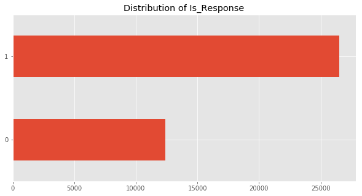

```python
import matplotlib
import matplotlib.pyplot as plt
import warnings
warnings.simplefilter('ignore', DeprecationWarning)
%matplotlib inline
plt.style.use('ggplot')

plt.figure(figsize=(10,5))
df['Is_Response'].value_counts(sort=True,ascending=True).plot(kind='barh')
plt.title('Distribution of Is_Response')

plt.show()
```

There are more happy response than unhappy response, about two times than unhappy.

```python
#https://github.com/Thakugan/machine-learning-notebooks/blob/master/8-recurrent-neural-networks/spam.ipynb
#there i want to show the length of the text
length = lambda X: len(X)
df["text_length"] = df["Description"].map(length)  # add a column indicating how long a text
print(df.head(10))
print("Mean length ",df["text_length"].mean())#print the mean length
```

```
                                         Description  Is_Response  text_length
0  The room was kind of clean but had a VERY stro...            0          248
1  I stayed at the Crown Plaza April -- - April -...            0         1077
2  I booked this hotel through Hotwire at the low...            0         1327
3  Stayed here with husband and sons on the way t...            1          502
4  My girlfriends and I stayed here to celebrate ...            0         1613
5  We had - rooms. One was very nice and clearly ...            1          610
6  My husband and I have stayed in this hotel a f...            0          492
7  My wife & I stayed in this glorious city a whi...            1          935
8  My boyfriend and I stayed at the Fairmont on a...            1          641
9  Wonderful staff, great location, but it was de...            0          358
Mean length  866.3808178362273
```

```python
import keras
from keras.preprocessing.text import Tokenizer
from keras.preprocessing.sequence import pad_sequences

NUM_TOP_WORDS = None #every unique word is ohe
MAX_ART_LEN = 1000 # maximum number of words

tokenizer = Tokenizer(num_words=NUM_TOP_WORDS)
tokenizer.fit_on_texts(X.tolist())
sequences = tokenizer.texts_to_sequences(X.tolist())

word_index = tokenizer.word_index
NUM_TOP_WORDS = len(word_index) if NUM_TOP_WORDS==None else NUM_TOP_WORDS
top_words = min((len(word_index),NUM_TOP_WORDS))
print('Found %s unique tokens. Distilled to %d top words.' % (len(word_index),top_words))

X = pad_sequences(sequences, maxlen=MAX_ART_LEN)

y_ohe = keras.utils.to_categorical(y)
print('Shape of data tensor:', X.shape)
print('Shape of label tensor:', y_ohe.shape)
print(np.max(X))
```

```
Found 49048 unique tokens. Distilled to 49048 top words.
Shape of data tensor: (38932, 1000)
Shape of label tensor: (38932, 2)
49048
```

After show the mean length of text is about 860, So I think set the maximum lenght of text to 1000 will be reasonable. And also I want every unique word is ohe. So the tokenizer will fit on every word and return ohe of text.

# Dividing training and testing

```python
from sklearn.model_selection import train_test_split
# Split it into train / test subsets
X_train, X_test, y_train_ohe, y_test_ohe = train_test_split(X, y_ohe, test_size=0.2,
                                                            stratify=y,
                                                            random_state=42)

X1_train, X1_test, y_train, y_test = train_test_split(X, y, test_size=0.2,stratify=y,
                                                            random_state=42)

NUM_CLASSES = 2
print(X_train.shape,y_train_ohe.shape)
print(np.sum(y_train_ohe,axis=0))
```

```
(31145, 1000) (31145, 2)
[ 9929. 21216.]
```

# Metric

The third party who interested in this result is hotels. They have millions of room reservations in a year. The quality of hotel service is important for the them. Customer will leave reviews on the website or with phone apps. Some customer will only leave the review without rating. So that we need a lot of human resources to check their reviews to know whether they are happy or not. My task is to predict the response of customers base on their reviews.

The performance of our model needs to be accurate in order to find out which the target reviews which are those who are not happy with hotel services, so we can send people to look their reviews and make some improvement. My metric is accuracy. Becasue my task is prediciton which class the review is. The accuracy directly reflect what is the ratio of my correction prediction. All other false positive and false negative are meaningless, because if it get wrong, the review need to check by human. The only correct classification can save time from human checking. If my accuracy is high, hotel can only check reviews which is unhappy, and do not need to check all reviews.

# Embedding

```python
EMBED_SIZE = 100
# the embed size should match the file you load glove from
embeddings_index = {}
f = open('glove.6B.100d.txt', encoding='utf8')
# save key/array pairs of the embeddings
#  the key of the dictionary is the word, the array is the embedding
for line in f:
    values = line.split()
    word = values[0]
    coefs = np.asarray(values[1:], dtype='float32')
    embeddings_index[word] = coefs
f.close()

print('Found %s word vectors.' % len(embeddings_index))

# now fill in the matrix, using the ordering from the
#  keras word tokenizer from before
embedding_matrix = np.zeros((len(word_index) + 1, EMBED_SIZE))
for word, i in word_index.items():
    embedding_vector = embeddings_index.get(word)
    if embedding_vector is not None:
        # words not found in embedding index will be all-zeros.
        embedding_matrix[i] = embedding_vector

print(embedding_matrix.shape)
```

```
Found 400000 word vectors.
(49049, 100)
```

```python
from keras.layers import Embedding

embedding_layer = Embedding(len(word_index) + 1,
                            EMBED_SIZE,
                            weights=[embedding_matrix],
                            input_length=MAX_ART_LEN,
                            trainable=False)
```

# Model1

```python
from keras.models import Sequential
from keras.layers import Dense
from keras.layers import LSTM

def rnn1_create():
    rnn1 = Sequential()
    rnn1.add(embedding_layer)
    rnn1.add(LSTM(100,dropout=0.2, recurrent_dropout=0.2))
    rnn1.add(Dense(NUM_CLASSES, activation='sigmoid'))
    rnn1.compile(loss='binary_crossentropy',
              optimizer='rmsprop',
              metrics=['accuracy'])

    return rnn1

rnn1 = rnn1_create()

print(rnn1.summary())
```

[output not shown]

```python
history1 = rnn1.fit(X_train, y_train_ohe, validation_data=(X_test, y_test_ohe), epochs=3, batch_size=64)
```

```
Train on 31145 samples, validate on 7787 samples
```

```python
#https://scikit-learn.org/stable/modules/generated/sklearn.model_selection.StratifiedKFold.html#sklearn.model_selection.StratifiedKFold.split
#https://github.com/Thakugan/machine-learning-notebooks/blob/master/6-wide-and-deep-networks/mushroom-hunting.ipynb
#I used this in last lab, just modified to new version
from sklearn.model_selection import StratifiedKFold
num_folds = 5

acc_scores1 =[]
skf1 = StratifiedKFold(n_splits=num_folds, shuffle=True)
for i, (train, test) in enumerate(skf1.split(X, y)):
    rnn1 = rnn1_create()
    #doing modeling same as above, without for loop

    rnn1.fit(X_train, y_train_ohe, validation_data=(X_test, y_test_ohe), epochs=3, batch_size=64)
    #this is just what i do without cross validation
    yhat = np.argmax(rnn1.predict(X_test), axis=1)

    acc_score1 = mt.accuracy_score(y_test,yhat)
    acc_scores1.append(acc_score1)
    print("Accuracy: ", acc_score1)
print(acc_scores1)
```

```
Train on 31145 samples, validate on 7787 samples
Accuracy:  0.8686271991781174
Train on 31145 samples, validate on 7787 samples
Accuracy:  0.869654552459227
Train on 31145 samples, validate on 7787 samples
Accuracy:  0.8692692949788109
Train on 31145 samples, validate on 7787 samples
Accuracy:  0.8491074868370361
Train on 31145 samples, validate on 7787 samples
Accuracy:  0.8684987800179786
[0.8686271991781174, 0.869654552459227, 0.8692692949788109, 0.8491074868370361, 0.8684987800179786]
```

```python
num_folds = 5

acc_scores2 =[]
skf1 = StratifiedKFold(n_splits=num_folds, shuffle=True)
for i, (train, test) in enumerate(skf1.split(X, y)):

    rnn1 = rnn1_create()
    #doing modeling same as above, without for loop

    rnn1.fit(X_train, y_train_ohe, validation_data=(X_test, y_test_ohe), epochs=3, batch_size=128)
    #this is just what i do without cross validation
    yhat = np.argmax(rnn1.predict(X_test), axis=1)

    acc_score2 = mt.accuracy_score(y_test,yhat)
    acc_scores2.append(acc_score2)
    print("Accuracy: ", acc_score2)
print(acc_scores2)
```

```
Train on 31145 samples, validate on 7787 samples
Accuracy:  0.865031462694234
Train on 31145 samples, validate on 7787 samples
Accuracy:  0.8622062411711827
Train on 31145 samples, validate on 7787 samples
Accuracy:  0.8506485167587003
Train on 31145 samples, validate on 7787 samples
Accuracy:  0.8632335944522923
Train on 31145 samples, validate on 7787 samples
Accuracy:  0.8600231154488249
[0.865031462694234, 0.8622062411711827, 0.8506485167587003, 0.8632335944522923, 0.8600231154488249]
```

```python
from keras.models import Sequential
from keras.layers import Dense
from keras.layers import LSTM

def rnn2_create():
    rnn2 = Sequential()
    rnn2.add(embedding_layer)
    rnn2.add(LSTM(100,dropout=0.2, recurrent_dropout=0.2))
    rnn2.add(Dense(NUM_CLASSES, activation='softmax'))
    rnn2.compile(loss='binary_crossentropy',
              optimizer='rmsprop',
              metrics=['accuracy'])
    return rnn2

rnn2 = rnn1_create()
print(rnn2.summary())
```

```
_________________________________________________________________
Layer (type)                 Output Shape              Param #
=================================================================
embedding_1 (Embedding)      (None, 1000, 100)         4904900
_________________________________________________________________
lstm_2 (LSTM)                (None, 100)               80400
_________________________________________________________________
dense_2 (Dense)              (None, 2)                 202
=================================================================
Total params: 4,985,502
Trainable params: 80,602
Non-trainable params: 4,904,900
_________________________________________________________________
None
```

```python
history2 = rnn2.fit(X_train, y_train_ohe, validation_data=(X_test, y_test_ohe), epochs=3, batch_size=64)
```

```python
num_folds = 5

acc_scores3 =[]
skf2 = StratifiedKFold(n_splits=num_folds, shuffle=True)
for i, (train, test) in enumerate(skf1.split(X, y)):

    rnn3 = rnn1_create()
    #doing modeling same as above, without for loop

    rnn3.fit(X_train, y_train_ohe, validation_data=(X_test, y_test_ohe), epochs=3, batch_size=128)
    #this is just what i do without cross validation
    yhat = np.argmax(rnn3.predict(X_test), axis=1)

    acc_score3 = mt.accuracy_score(y_test,yhat)
    acc_scores3.append(acc_score3)
    print("Accuracy: ", acc_score3)
print(acc_scores3)
```

```
Train on 31145 samples, validate on 7787 samples
Accuracy:  0.8642609477334018
Train on 31145 samples, validate on 7787 samples
Accuracy:  0.8633620136124309
Train on 31145 samples, validate on 7787 samples
Accuracy:  0.8528316424810581
Train on 31145 samples, validate on 7787 samples
Accuracy:  0.8297161936560935
Train on 31145 samples, validate on 7787 samples
Accuracy:  0.8573263130859125
[0.8642609477334018, 0.8633620136124309, 0.8528316424810581, 0.8297161936560935, 0.8573263130859125]
```

```python
t = 2.26 / np.sqrt(10)
e = (1-np.array(acc_scores1))-(1-np.array(acc_scores2))
stdtot =np.std(e)

dbar = np.mean(e)
print('model1 64 vs model1 128 acc range :',dbar-t*stdtot,dbar+t*stdtot)
```

```
model1 64 vs model1 128 acc range : -0.01244144745665008 0.002835694278275837
```

Becasue the range is include 0, so we can not say that with 95% confident level, model1 64 and model1 128 are statisitcally different base on accuracy.

```python
from statistics import mean
print('Average accuracy for model1 64 ',mean(acc_scores1))
print('Average accuracy for model1 128 ',mean(acc_scores2))
```

```
Average accuracy for model1 64  0.8650314626942339
Average accuracy for model1 128  0.8602285861050468
```

Base on average accuracy, model 64 batch size is litte bit better.

```python
t = 2.26 / np.sqrt(10)
e = (1-np.array(acc_scores1))-(1-np.array(acc_scores3))
stdtot =np.std(e)

dbar = np.mean(e)
print('model1 64 vs model1 softmax acc range :',dbar-t*stdtot,dbar+t*stdtot)
```

```
model1 64 vs model1 softmax acc range : -0.015634585971797028 -0.007429495189112228
```

```python
print('Average accuracy for model1 64 ',mean(acc_scores1))
print('Average accuracy for model1 softmax ',mean(acc_scores3))
```

```
Average accuracy for model1 64  0.8650314626942339
Average accuracy for model1 softmax  0.8534994221137794
```

# Model2 GRU

```python
from keras.models import Sequential, Input, Model
from keras.layers import Dense
from keras.layers import LSTM, GRU, SimpleRNN
from keras.layers.embeddings import Embedding

def rnn3_create():
    rnn_gru3 = Sequential()
    rnn_gru3.add(embedding_layer)
    rnn_gru3.add(GRU(100,dropout=0.2, recurrent_dropout=0.2))
    rnn_gru3.add(Dense(NUM_CLASSES, activation='sigmoid'))
    rnn_gru3.compile(loss='binary_crossentropy',
                  optimizer='rmsprop',
                  metrics=['accuracy'])
    return rnn_gru3

rnn_gru3 = rnn3_create()

print(rnn_gru3.summary())
```

```
_________________________________________________________________
Layer (type)                 Output Shape              Param #
=================================================================
embedding_1 (Embedding)      (None, 1000, 100)         4904900
_________________________________________________________________
gru_1 (GRU)                  (None, 100)               60300
_________________________________________________________________
dense_3 (Dense)              (None, 2)                 202
=================================================================
Total params: 4,965,402
Trainable params: 60,502
Non-trainable params: 4,904,900
_________________________________________________________________
None
```

```python
history4 = rnn_gru3.fit(X_train, y_train_ohe, validation_data=(X_test, y_test_ohe), epochs=3, batch_size=64)
```

```
Train on 31145 samples, validate on 7787 samples
```

```python
num_folds = 5

acc_scores4 =[]
skf3 = StratifiedKFold(n_splits=num_folds, shuffle=True)
for i, (train, test) in enumerate(skf1.split(X, y)):

    rnn_gru3 = rnn3_create()
    #doing modeling same as above, without for loop

    rnn_gru3.fit(X_train, y_train_ohe, validation_data=(X_test, y_test_ohe), epochs=3, batch_size=64)
    #this is just what i do without cross validation
    yhat = np.argmax(rnn_gru3.predict(X_test), axis=1)

    acc_score4 = mt.accuracy_score(y_test,yhat)
    acc_scores4.append(acc_score4)
    print("Accuracy: ", acc_score4)
print(acc_scores4)
```

```
Train on 31145 samples, validate on 7787 samples
Accuracy:  0.8814691151919867
Train on 31145 samples, validate on 7787 samples
Accuracy:  0.8831385642737897
Train on 31145 samples, validate on 7787 samples
Accuracy:  0.8815975343521253
Train on 31145 samples, validate on 7787 samples
Accuracy:  0.8846795941954539
Train on 31145 samples, validate on 7787 samples
Accuracy:  0.8741492230640812
[0.8814691151919867, 0.8831385642737897, 0.8815975343521253, 0.8846795941954539, 0.8741492230640812]
```

```python
num_folds = 5

acc_scores5 =[]
skf3 = StratifiedKFold(n_splits=num_folds, shuffle=True)
for i, (train, test) in enumerate(skf1.split(X, y)):

    rnn_gru3 = rnn3_create()
    #doing modeling same as above, without for loop

    rnn_gru3.fit(X_train, y_train_ohe, validation_data=(X_test, y_test_ohe), epochs=3, batch_size=128)
    #this is just what i do without cross validation
    yhat = np.argmax(rnn_gru3.predict(X_test), axis=1)

    acc_score5 = mt.accuracy_score(y_test,yhat)
    acc_scores5.append(acc_score5)
    print("Accuracy: ", acc_score5)
print(acc_scores5)
```

```
Train on 31145 samples, validate on 7787 samples
Accuracy:  0.8782586361885193
Train on 31145 samples, validate on 7787 samples
Accuracy:  0.8745344805444972
Train on 31145 samples, validate on 7787 samples
Accuracy:  0.8756902529857454
Train on 31145 samples, validate on 7787 samples
Accuracy:  0.8777449595479646
Train on 31145 samples, validate on 7787 samples
Accuracy:  0.8727366123025555
[0.8782586361885193, 0.8745344805444972, 0.8756902529857454, 0.8777449595479646, 0.8727366123025555]
```

```python
def rnn4_create():
    rnn_gru4 = Sequential()
    rnn_gru4.add(embedding_layer)
    rnn_gru4.add(GRU(100,dropout=0.2, recurrent_dropout=0.2))
    rnn_gru4.add(Dense(NUM_CLASSES, activation='softmax'))
    rnn_gru4.compile(loss='binary_crossentropy',
                  optimizer='rmsprop',
                  metrics=['accuracy'])
    return rnn_gru4

rnn_gru4 = rnn4_create()

print(rnn_gru4.summary())
```

```
_________________________________________________________________
Layer (type)                 Output Shape              Param #
=================================================================
embedding_1 (Embedding)      (None, 1000, 100)         4904900
_________________________________________________________________
gru_2 (GRU)                  (None, 100)               60300
_________________________________________________________________
dense_4 (Dense)              (None, 2)                 202
=================================================================
Total params: 4,965,402
Trainable params: 60,502
Non-trainable params: 4,904,900
_________________________________________________________________
None
```

```python
num_folds = 5

acc_scores6 =[]
skf3 = StratifiedKFold(n_splits=num_folds, shuffle=True)
for i, (train, test) in enumerate(skf1.split(X, y)):

    rnn_gru4 = rnn4_create()
    #doing modeling same as above, without for loop

    rnn_gru4.fit(X_train, y_train_ohe, validation_data=(X_test, y_test_ohe), epochs=3, batch_size=64)
    #this is just what i do without cross validation
    yhat = np.argmax(rnn_gru4.predict(X_test), axis=1)

    acc_score6 = mt.accuracy_score(y_test,yhat)
    acc_scores6.append(acc_score6)
    print("Accuracy: ", acc_score6)
print(acc_scores6)
```

```
Train on 31145 samples, validate on 7787 samples
Accuracy:  0.8844227558751766
Train on 31145 samples, validate on 7787 samples
Accuracy:  0.8841659175548992
Train on 31145 samples, validate on 7787 samples
Accuracy:  0.8804417619108771
Train on 31145 samples, validate on 7787 samples
Accuracy:  0.8551431873635547
Train on 31145 samples, validate on 7787 samples
Accuracy:  0.8715808398613073
[0.8844227558751766, 0.8841659175548992, 0.8804417619108771, 0.8551431873635547, 0.8715808398613073]
```

```python
t = 2.26 / np.sqrt(10)
e = (1-np.array(acc_scores4))-(1-np.array(acc_scores5))
stdtot =np.std(e)

dbar = np.mean(e)
print('model2 64 vs model2 128 acc range :',dbar-t*stdtot,dbar+t*stdtot)
```

```
model2 64 vs model2 128 acc range : -0.007060904348436647 -0.0033667314548252217
```

Becasue the range is not include 0, so we can say that with 95% confident level, model2 64 and model2 128 are statisitcally different base on accuracy.

```python
print('Average accuracy for model2 64 ',mean(acc_scores4))
print('Average accuracy for model2 128 ',mean(acc_scores5))
```

```
Average accuracy for model2 64  0.8810068062154872
Average accuracy for model2 128  0.8757929883138564
```

Base on average accuracy, model2 64 is better.

```python
t = 2.26 / np.sqrt(10)
e = (1-np.array(acc_scores4))-(1-np.array(acc_scores6))
stdtot =np.std(e)

dbar = np.mean(e)
print('model2 64 vs model2 softmax acc range :',dbar-t*stdtot,dbar+t*stdtot)
```

[output not shown]

```python
print('Average accuracy for model2 64 ',mean(acc_scores4))
print('Average accuracy for model2 softmax ',mean(acc_scores6))
```

```
Average accuracy for model2 64  0.8810068062154872
Average accuracy for model2 softmax  0.8751508925131629
```

Base on average accuracy, model2 64 is better.

For model2, model2 with sigmoid and 64 batch size is better.

```python
t = 2.26 / np.sqrt(10)
e = (1-np.array(acc_scores1))-(1-np.array(acc_scores4))
stdtot =np.std(e)

dbar = np.mean(e)
print('model1 64 vs model2 64 acc range :',dbar-t*stdtot,dbar+t*stdtot)
```

```
model1 64 vs model2 64 acc range : 0.008687320463473508 0.02326336657903321
```

Becasue the range is not include 0, so we can say that with 95% confident level, model1 64 and model2 64 are statisitcally different base on accuracy.

```python
print('Average accuracy for model1 64 ',mean(acc_scores1))
print('Average accuracy for model2 64 ',mean(acc_scores4))
```

```
Average accuracy for model1 64  0.8650314626942339
Average accuracy for model2 64  0.8810068062154872
```

Base on average accuracy, model2 64 is better.

### Model2 with 64 batch size and sigmoid is better.

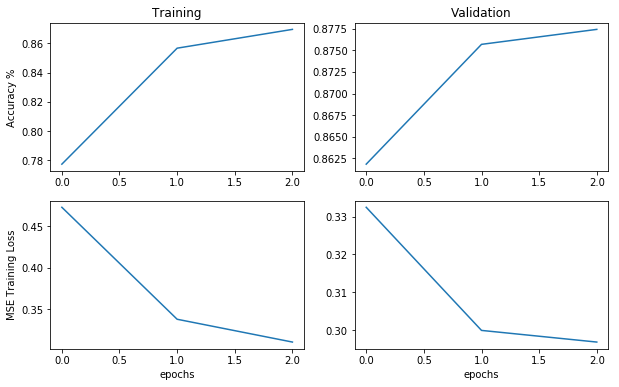

```python
from matplotlib import pyplot as plt

%matplotlib inline

plt.figure(figsize=(10,6))
plt.subplot(2,2,1)
plt.plot(history4.history['acc'])

plt.ylabel('Accuracy %')
plt.title('Training')
plt.subplot(2,2,2)
plt.plot(history4.history['val_acc'])
plt.title('Validation')

plt.subplot(2,2,3)
plt.plot(history4.history['loss'])
plt.ylabel('MSE Training Loss')
plt.xlabel('epochs')

plt.subplot(2,2,4)
plt.plot(history4.history['val_loss'])
plt.xlabel('epochs')
```

# Second recurrent chain

```python
from keras.models import Sequential, Input, Model
from keras.layers import Dense
from keras.layers import LSTM, GRU, SimpleRNN
from keras.layers.embeddings import Embedding

def rnn7_create():
    rnn_gru7 = Sequential()
    rnn_gru7.add(embedding_layer)

    rnn_gru7.add(GRU(100,dropout=0.2, recurrent_dropout=0.2,return_sequences=True))#add a second recurrent chain to your RNN

    rnn_gru7.add(GRU(100,dropout=0.2, recurrent_dropout=0.2))
    rnn_gru7.add(Dense(NUM_CLASSES, activation='sigmoid'))
    rnn_gru7.compile(loss='binary_crossentropy',
                  optimizer='rmsprop',
                  metrics=['accuracy'])
    return rnn_gru7

rnn_gru7 = rnn7_create()

print(rnn_gru7.summary())
```

[output not shown]

```python
history7 = rnn_gru7.fit(X_train, y_train_ohe, validation_data=(X_test, y_test_ohe), epochs=3, batch_size=64)
```

```
Train on 31145 samples, validate on 7787 samples
```

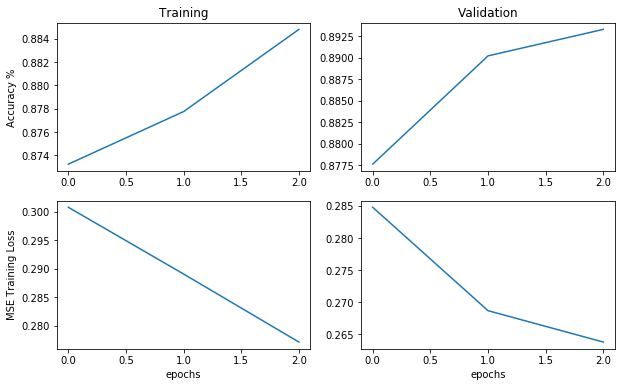

```python
from matplotlib import pyplot as plt

%matplotlib inline

plt.figure(figsize=(10,6))
plt.subplot(2,2,1)
plt.plot(history7.history['acc'])

plt.ylabel('Accuracy %')
plt.title('Training')
plt.subplot(2,2,2)
plt.plot(history7.history['val_acc'])
plt.title('Validation')

plt.subplot(2,2,3)
plt.plot(history7.history['loss'])
plt.ylabel('MSE Training Loss')
plt.xlabel('epochs')

plt.subplot(2,2,4)
plt.plot(history7.history['val_loss'])
plt.xlabel('epochs')
```

# Exceptional Work

I will paticipate the Seminar Research Study on 17th of may 1pm.

[figure not shown]

```python
from PIL import Image

plt.figure(figsize=(100,50))

img = Image.open('d10b59955278539f3dc78a818e0307a.png')
plt.subplot(3,1,1)
plt.imshow(img)
img1 = Image.open('33b07f786e91f2048d04da7034cc0ad.png')
plt.subplot(3,1,2)
plt.imshow(img1)
plt.subplot(3,1,3)
img2 = Image.open('f1bc574092a564dd5937407fc512ac5.png')
plt.imshow(img2)
```